# Distribuciones de Probabilidad

Breve resumen del manejo de las funciones básicas de probabilidad con las funcinones incluídas por defecto en R

## Nombres o ‘alias’ de las distribuciones más frecuentes

- Distribución Binomial: binom
- Distribución de Poisson: pois
- Distribución normal: norm
- Distribución exponencial: exp
- Distribución t de Student: t
- Distribución Chi cuadrado : chisq
- Distribución F : f

Para obtener una lista completa de las distribuciones que R maneja basta escribir help(“Distributions”“):

## Funciones relacionadas

Para cada una de las distribuciones, tenemos cuatro funciones relacionadas. En R tenemos un prefijo para acceder a cada una de ellas.

- Función de distribución: p
- Función cuantílica (la que nos da el percentil): q
- Función de densidad (distribuciones continuas) o probabilidad (discretas): d
- Generación de números aleatorios: r

Por ejemplo, dexp(x) es la función de densidad de una exponencial de media 1.

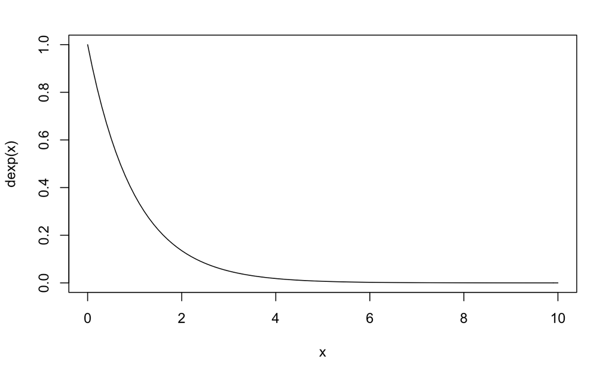

`r`r x <- rbinom(20, 1, 0.5) # Genera 20 observaciones con distribución B(1,0.5) x

```
 [1] 0 1 0 1 0 0 1 1 0 0 1 0 0 0 1 0 0 0 0 0
```

`r`r table(x) # Calcula las fecuencias absolutas de los valores generados

```
x
 0  1
14  6
```

## Ejemplo: la distribución normal

Supongamos que tenemos X, una variable aleatoria que sigue una distribución normal de media 3 y desviación típica 0.5. La probabilidad de que nuestra X sea menor que 3.5 la calculamos de la siguiente manera:

`r`r pnorm(3.5, mean = 3, sd = .5)

```
[1] 0.8413447
```

Para encontrar el cuantil 0.7 de una variable aleatoria que sigue una distribución normal estándar:

`r`r qnorm(0.7)

```
[1] 0.5244005
```

Si queremos lo mismo pero nuestra variable aleatoria ahora tiene una media de 0 y una desviación típica de 0.5:

`r`r qnorm(0.7, sd = 0.5)

```
[1] 0.2622003
```

Un valor Z muy común en fórmulas para intervalos y constantes se obtiene con el comando qnorm(1-alfa).

`r`r qnorm(0.955)

```
[1] 1.695398
```

`r`r qnorm(0.99)

```
[1] 2.326348
```

Si queremos generar una muestra tamaño 100 de una población normal de media 10 y desviación típica 1:

`r`r x <- rnorm(100, mean = 10, sd = 1) x

```
  [1]  9.819223 10.277342 11.976510  9.268454 11.505740 10.013086 10.736725  9.799676  8.831030 10.255905 11.504595  9.950207 11.749160 11.277474  9.242091
 [16] 10.782830  9.001001  9.386048  9.627009  8.345630  8.402467 11.897098 11.037191  8.977794  9.909489 10.944017  8.625520  9.854752 10.332962  8.455403
 [31] 10.900135  9.058989  8.503203  8.456458  9.575249  8.978584 10.207255  7.764244  9.982543  9.731423  9.597457  7.886971 10.238669 11.522112  9.618912
 [46]  9.995982  9.268292  9.350520  9.860230  8.929114 11.928655 10.102221 11.347496  8.202744  9.245104  9.725443 12.210105  9.639125  8.486897 10.406365
 [61] 10.806897 10.884230 10.227525  9.791876  8.343279  8.925330 10.713647  9.389930 10.411788 10.422756 10.402916  8.503644  8.443597 11.713952 10.049616
 [76] 11.705770  9.558712 10.199520  9.129603  8.956802 10.850496 10.865270  8.470806 11.355328 10.116756 10.263830  8.831020 10.870905  8.564563 11.828045
 [91]  9.356414 10.911768 10.062787 10.874669  9.452829  8.549199  9.363679  8.774328 10.171443 10.394552
```

`r`r mean(x)

```
[1] 9.91017
```

`r`r sd(x)

```
[1] 1.063621
```

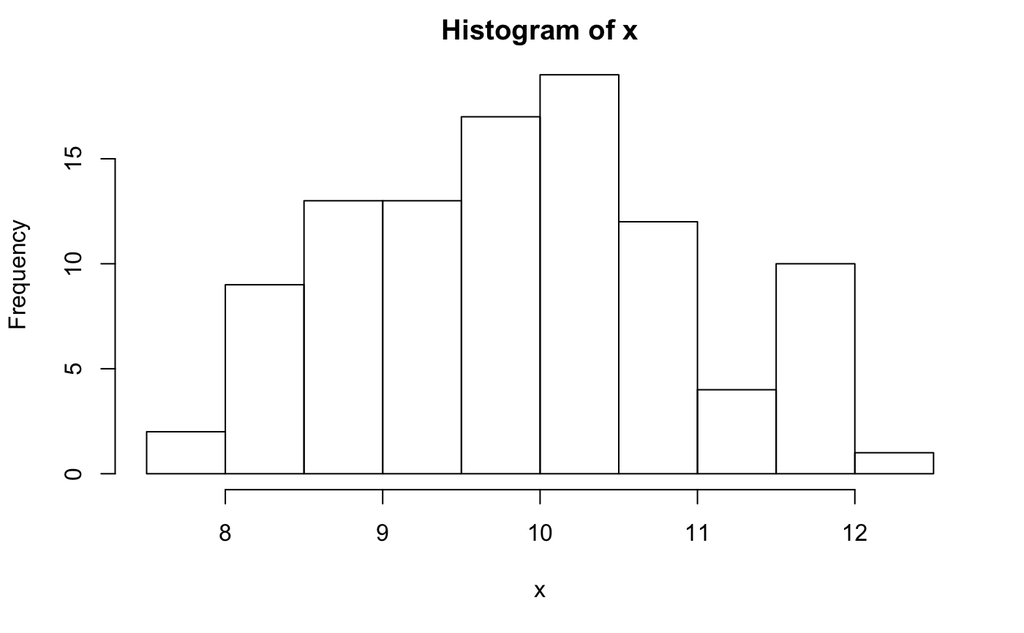

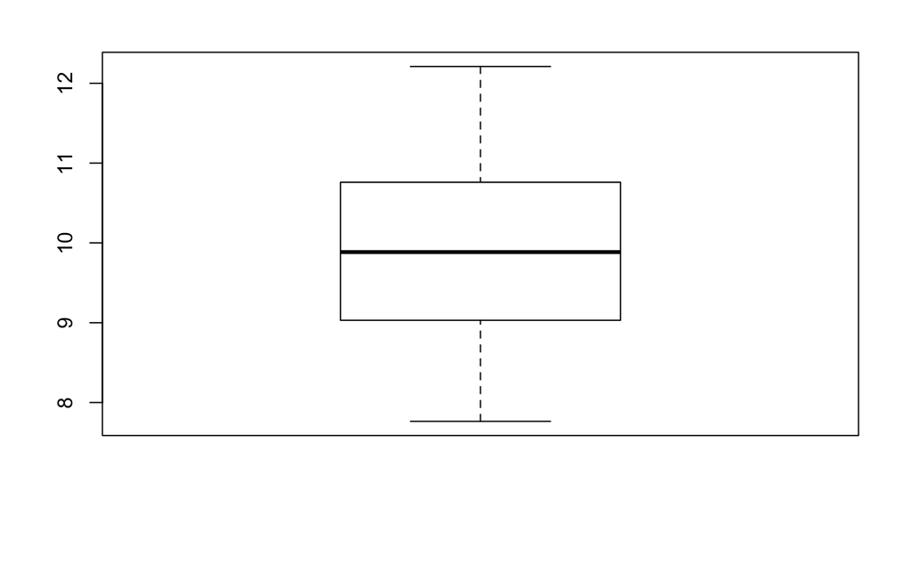

Representamos ahora el histograma normalizado de la muestra junto con la densidad de la población:

`r`r hist(x, freq = FALSE) # freq = FALSE para que el área total sea 1 curve(dnorm(x, mean = 10, sd = 1), from = 7, to = 13, add = TRUE)

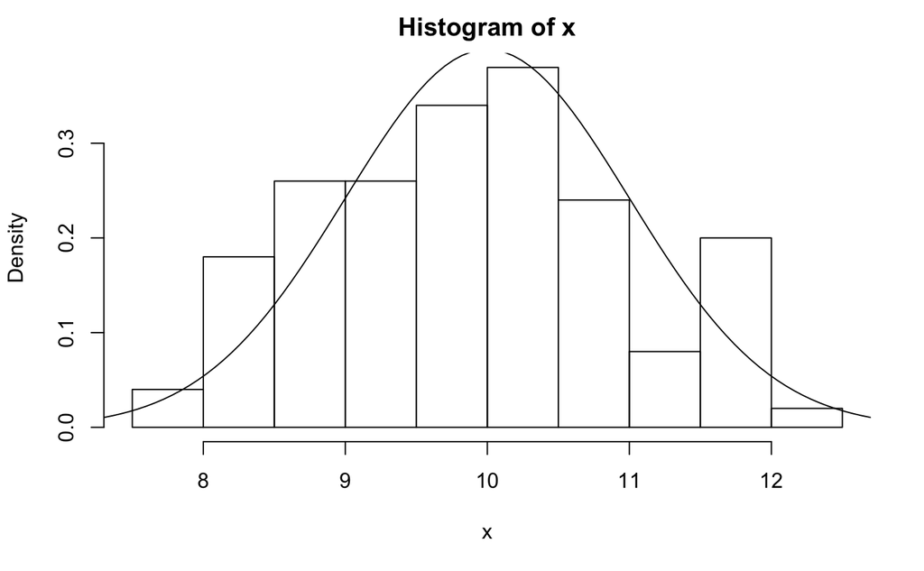

## Referencias

http://rpubs.com/joser/distribuciones